# Clustering and classification

This week we will learn about clustering and classifying data.

First we load up the Boston data from MASS package (https://stat.ethz.ch/R-manual/R-devel/library/MASS/html/Boston.html).

```r
# load up the MASS package and then boston
library(MASS)
data("Boston")
```

Let’s explore the data. As this data is loaded straight from the package we don’t have an extra id column at start like in the previous weeks with the wrangled data.

```r
# we use str and summary functions
str(Boston)
```

```
## 'data.frame':    506 obs. of  14 variables:
##  $ crim   : num  0.00632 0.02731 0.02729 0.03237 0.06905 ...
##  $ zn     : num  18 0 0 0 0 0 12.5 12.5 12.5 12.5 ...
##  $ indus  : num  2.31 7.07 7.07 2.18 2.18 2.18 7.87 7.87 7.87 7.87 ...
##  $ chas   : int  0 0 0 0 0 0 0 0 0 0 ...
##  $ nox    : num  0.538 0.469 0.469 0.458 0.458 0.458 0.524 0.524 0.524 0.524 ...
##  $ rm     : num  6.58 6.42 7.18 7 7.15 ...
##  $ age    : num  65.2 78.9 61.1 45.8 54.2 58.7 66.6 96.1 100 85.9 ...
##  $ dis    : num  4.09 4.97 4.97 6.06 6.06 ...
##  $ rad    : int  1 2 2 3 3 3 5 5 5 5 ...
##  $ tax    : num  296 242 242 222 222 222 311 311 311 311 ...
##  $ ptratio: num  15.3 17.8 17.8 18.7 18.7 18.7 15.2 15.2 15.2 15.2 ...
##  $ black  : num  397 397 393 395 397 ...
##  $ lstat  : num  4.98 9.14 4.03 2.94 5.33 ...
##  $ medv   : num  24 21.6 34.7 33.4 36.2 28.7 22.9 27.1 16.5 18.9 ...
```

```r
summary(Boston)
```

```
##       crim                zn             indus            chas
##  Min.   : 0.00632   Min.   :  0.00   Min.   : 0.46   Min.   :0.00000
##  1st Qu.: 0.08205   1st Qu.:  0.00   1st Qu.: 5.19   1st Qu.:0.00000
##  Median : 0.25651   Median :  0.00   Median : 9.69   Median :0.00000
##  Mean   : 3.61352   Mean   : 11.36   Mean   :11.14   Mean   :0.06917
##  3rd Qu.: 3.67708   3rd Qu.: 12.50   3rd Qu.:18.10   3rd Qu.:0.00000
##  Max.   :88.97620   Max.   :100.00   Max.   :27.74   Max.   :1.00000
##       nox               rm             age              dis
##  Min.   :0.3850   Min.   :3.561   Min.   :  2.90   Min.   : 1.130
##  1st Qu.:0.4490   1st Qu.:5.886   1st Qu.: 45.02   1st Qu.: 2.100
##  Median :0.5380   Median :6.208   Median : 77.50   Median : 3.207
##  Mean   :0.5547   Mean   :6.285   Mean   : 68.57   Mean   : 3.795
##  3rd Qu.:0.6240   3rd Qu.:6.623   3rd Qu.: 94.08   3rd Qu.: 5.188
##  Max.   :0.8710   Max.   :8.780   Max.   :100.00   Max.   :12.127
##       rad              tax           ptratio          black
##  Min.   : 1.000   Min.   :187.0   Min.   :12.60   Min.   :  0.32
##  1st Qu.: 4.000   1st Qu.:279.0   1st Qu.:17.40   1st Qu.:375.38
##  Median : 5.000   Median :330.0   Median :19.05   Median :391.44
##  Mean   : 9.549   Mean   :408.2   Mean   :18.46   Mean   :356.67
##  3rd Qu.:24.000   3rd Qu.:666.0   3rd Qu.:20.20   3rd Qu.:396.23
##  Max.   :24.000   Max.   :711.0   Max.   :22.00   Max.   :396.90
##      lstat            medv
##  Min.   : 1.73   Min.   : 5.00
##  1st Qu.: 6.95   1st Qu.:17.02
##  Median :11.36   Median :21.20
##  Mean   :12.65   Mean   :22.53
##  3rd Qu.:16.95   3rd Qu.:25.00
##  Max.   :37.97   Max.   :50.00
```

This is a pre-made data available with the MASS package with 14 variables and 506 observations. The 14 columns are as follow:

1. **crim** per capita crime rate by town.
2. **zn** proportion of residential land zoned for lots over 25,000 sq.ft.
3. **indus** proportion of non-retail business acres per town.
4. **chas** Charles River dummy variable (= 1 if tract bounds river; 0 otherwise).
5. **nox** nitrogen oxides concentration (parts per 10 million).
6. **rm** average number of rooms per dwelling.
7. **age** proportion of owner-occupied units built prior to 1940.
8. **dis** weighted mean of distances to five Boston employment centres.
9. **rad** index of accessibility to radial highways.
10. **tax** full-value property-tax rate per $10,000.
11. **ptratio** pupil-teacher ratio by town.
12. **black** 1000(Bk - 0.63)^2 where Bk is the proportion of blacks by town.
13. **lstat** lower status of the population (percent).
14. **medv** median value of owner-occupied homes in $1000s.

Let us visualize the data with the *pairs*-function for a portion of the data (the full set of 14 variables is too much for the pairs function to print out in a readable form).

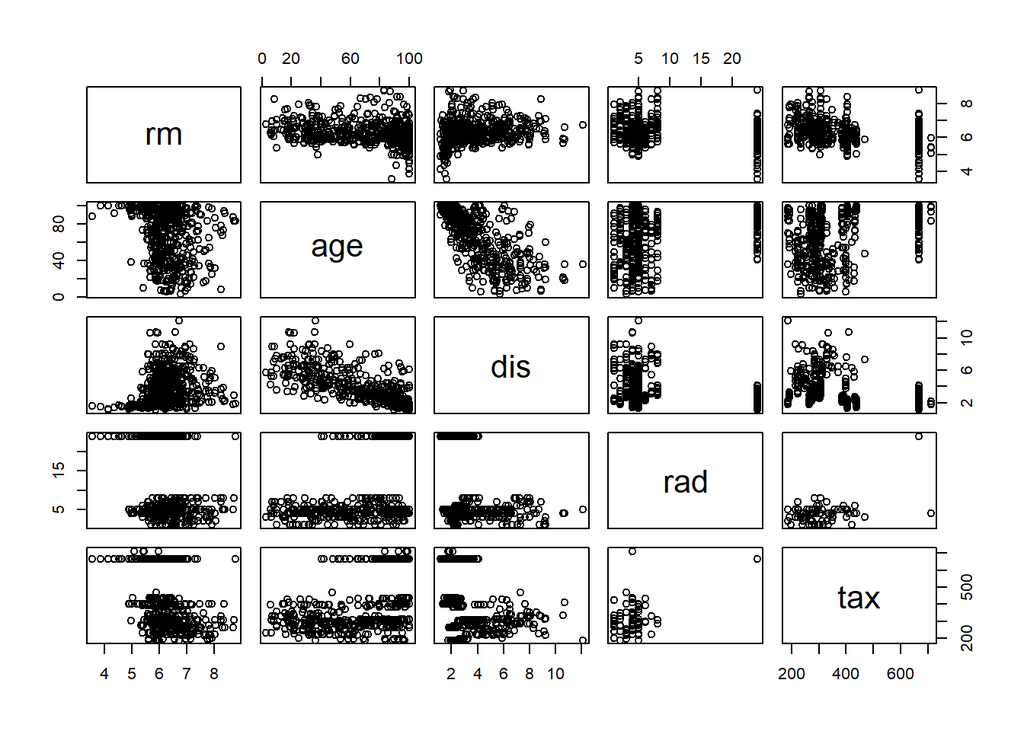

```r
pairs(Boston[6:10])
```

This is not entirely useful so let us try the *corrplot*-package, we also load the *dplyr*-package.

```r
# first load the the corrplot and dplyr package
library(corrplot)
library(dplyr)
# show a correlation matrix with digits rounded to 2
cor_matrix = cor(Boston, use = "pairwise")
cor_matrix %>% round(digits = 2)
```

```
##          crim    zn indus  chas   nox    rm   age   dis   rad   tax ptratio
## crim     1.00 -0.20  0.41 -0.06  0.42 -0.22  0.35 -0.38  0.63  0.58    0.29
## zn      -0.20  1.00 -0.53 -0.04 -0.52  0.31 -0.57  0.66 -0.31 -0.31   -0.39
## indus    0.41 -0.53  1.00  0.06  0.76 -0.39  0.64 -0.71  0.60  0.72    0.38
## chas    -0.06 -0.04  0.06  1.00  0.09  0.09  0.09 -0.10 -0.01 -0.04   -0.12
## nox      0.42 -0.52  0.76  0.09  1.00 -0.30  0.73 -0.77  0.61  0.67    0.19
## rm      -0.22  0.31 -0.39  0.09 -0.30  1.00 -0.24  0.21 -0.21 -0.29   -0.36
## age      0.35 -0.57  0.64  0.09  0.73 -0.24  1.00 -0.75  0.46  0.51    0.26
## dis     -0.38  0.66 -0.71 -0.10 -0.77  0.21 -0.75  1.00 -0.49 -0.53   -0.23
## rad      0.63 -0.31  0.60 -0.01  0.61 -0.21  0.46 -0.49  1.00  0.91    0.46
## tax      0.58 -0.31  0.72 -0.04  0.67 -0.29  0.51 -0.53  0.91  1.00    0.46
## ptratio  0.29 -0.39  0.38 -0.12  0.19 -0.36  0.26 -0.23  0.46  0.46    1.00
## black   -0.39  0.18 -0.36  0.05 -0.38  0.13 -0.27  0.29 -0.44 -0.44   -0.18
## lstat    0.46 -0.41  0.60 -0.05  0.59 -0.61  0.60 -0.50  0.49  0.54    0.37
## medv    -0.39  0.36 -0.48  0.18 -0.43  0.70 -0.38  0.25 -0.38 -0.47   -0.51
##         black lstat  medv
## crim    -0.39  0.46 -0.39
## zn       0.18 -0.41  0.36
## indus   -0.36  0.60 -0.48
## chas     0.05 -0.05  0.18
## nox     -0.38  0.59 -0.43
## rm       0.13 -0.61  0.70
## age     -0.27  0.60 -0.38
## dis      0.29 -0.50  0.25
## rad     -0.44  0.49 -0.38
## tax     -0.44  0.54 -0.47
## ptratio -0.18  0.37 -0.51
## black    1.00 -0.37  0.33
## lstat   -0.37  1.00 -0.74
## medv     0.33 -0.74  1.00
```

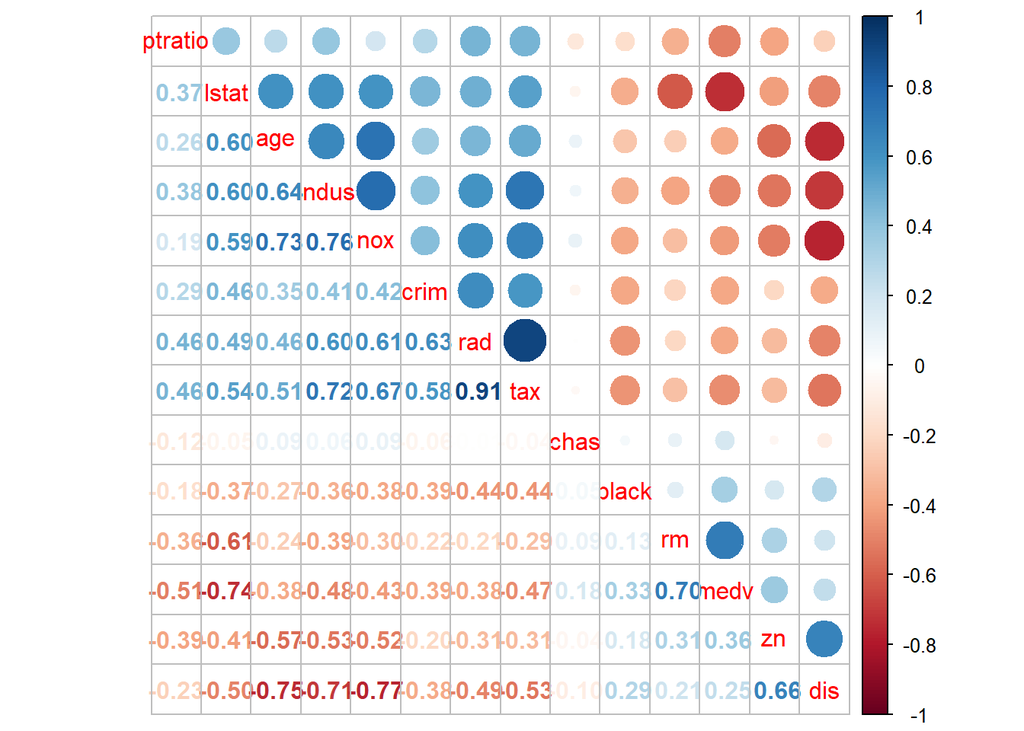

```r
# visualizing the corrplot matrix
corrplot.mixed(cor_matrix, order="hclust")
```

From the corrplot values and images we can see strong (>0.50) correlations between several variables. The dummy variable chas unsuprisingly does not correlate with the others strongly.

The variables seem to divide in two regarding correlation with each other. Inside the variables corrolate with each other positively but negatively with the the other group of variables.

1. ptratio, lstat, ag, indus, nox, crim, rad and tax.
2. black, rm, medv, zn, dis

Next let us standardize the variables using the *scale*-function.

```r
# use the scale function on the dataset
boston_s = scale(Boston)
```

Summarizing the new scaled and centered variables.

```r
summary(boston_s)
```

```
##       crim                 zn               indus              chas
##  Min.   :-0.419367   Min.   :-0.48724   Min.   :-1.5563   Min.   :-0.2723
##  1st Qu.:-0.410563   1st Qu.:-0.48724   1st Qu.:-0.8668   1st Qu.:-0.2723
##  Median :-0.390280   Median :-0.48724   Median :-0.2109   Median :-0.2723
##  Mean   : 0.000000   Mean   : 0.00000   Mean   : 0.0000   Mean   : 0.0000
##  3rd Qu.: 0.007389   3rd Qu.: 0.04872   3rd Qu.: 1.0150   3rd Qu.:-0.2723
##  Max.   : 9.924110   Max.   : 3.80047   Max.   : 2.4202   Max.   : 3.6648
##       nox                rm               age               dis
##  Min.   :-1.4644   Min.   :-3.8764   Min.   :-2.3331   Min.   :-1.2658
##  1st Qu.:-0.9121   1st Qu.:-0.5681   1st Qu.:-0.8366   1st Qu.:-0.8049
##  Median :-0.1441   Median :-0.1084   Median : 0.3171   Median :-0.2790
##  Mean   : 0.0000   Mean   : 0.0000   Mean   : 0.0000   Mean   : 0.0000
##  3rd Qu.: 0.5981   3rd Qu.: 0.4823   3rd Qu.: 0.9059   3rd Qu.: 0.6617
##  Max.   : 2.7296   Max.   : 3.5515   Max.   : 1.1164   Max.   : 3.9566
##       rad               tax             ptratio            black
##  Min.   :-0.9819   Min.   :-1.3127   Min.   :-2.7047   Min.   :-3.9033
##  1st Qu.:-0.6373   1st Qu.:-0.7668   1st Qu.:-0.4876   1st Qu.: 0.2049
##  Median :-0.5225   Median :-0.4642   Median : 0.2746   Median : 0.3808
##  Mean   : 0.0000   Mean   : 0.0000   Mean   : 0.0000   Mean   : 0.0000
##  3rd Qu.: 1.6596   3rd Qu.: 1.5294   3rd Qu.: 0.8058   3rd Qu.: 0.4332
##  Max.   : 1.6596   Max.   : 1.7964   Max.   : 1.6372   Max.   : 0.4406
##      lstat              medv
##  Min.   :-1.5296   Min.   :-1.9063
##  1st Qu.:-0.7986   1st Qu.:-0.5989
##  Median :-0.1811   Median :-0.1449
##  Mean   : 0.0000   Mean   : 0.0000
##  3rd Qu.: 0.6024   3rd Qu.: 0.2683
##  Max.   : 3.5453   Max.   : 2.9865
```

We can see the class of the scaled and centered object with *class*.

```r
class(boston_s)
```

```
## [1] "matrix" "array"
```

Let’s make the matrix variable into a new data frame.

```r
# using the as.data.frame on the matrix
boston_scaled = as.data.frame(boston_s)
```

The scaling effectively changes the variables into a z-scores by substracting the values with its expected value and dividing this difference by its standard deviation.

Next we create a categorical variable of the crime rate from the scaled Boston dataset. First we compute the quantiles of the crim variable

```r
# create a new quantile vector called bins and check it
bins = quantile(boston_scaled$crim)
bins
```

```
##           0%          25%          50%          75%         100%
## -0.419366929 -0.410563278 -0.390280295  0.007389247  9.924109610
```

Next we use the quantile vector to create a new variable. We will also name the categories made with the quantile vector as follows:

0-25 low

25-50 med_low

50-75 med_high

75-100 high

```r
# create a factorial variabl with cut function and using the quantile of boston_scaled$crim as breaks, also label the new categories accordingly.
crime = cut(boston_scaled$crim, breaks = bins, include.lowest = TRUE, labels = c("low", "med_low", "med_high", "high"))
```

Lets have a look at our categorical variable.

```r
table(crime)
```

```
## crime
##      low  med_low med_high     high
##      127      126      126      127
```

These now seem to confer to the quantile vector with roughly equal sizes.

We are now ready to remove the original variable and insert the new variable to the data set.

```r
# use the dplyr:: handle so in case another package also has a similarly named function
boston_scaled = dplyr::select(boston_scaled, -crim)
boston_scaled = data.frame(boston_scaled, crime)
```

Next we divide the data set between a training set(80%) and test set(20%). We start by getting the row number (aka number of observations) for boston_scaled. From there we can choose 80% with the *sample*-function.

```r
# row and sample size
n = nrow(boston_scaled)
ind = sample(n, size = n*0.8)

# train and test set
train = boston_scaled[ind,]
test = boston_scaled[-ind,]
```

Next we save up the test data set crime and remove it.

```r
# save the crime column of test data set and remove it with select, call dplyr:: just in case again
correct_classes = test$crime
test = dplyr::select(test, -crime)
```

Now we are ready to do some analysis with the linear discriminant method. This method finds the linear combination of the variables that separate the target variable classes. This time our target variable will be the crime variable from the train data set. We do the analysis with the *lda*-function.

```r
table(train$crime)
```

```
##
##      low  med_low med_high     high
##      109       95      100      100
```

```r
# use of lda is similar to linear regression model, we also use the ~. to indicate the function to use all variables available in the data set
# we utilize the MASS-package, note that this will mask select from dplyr-package which is why used the dplyr:: earlier
library(MASS)
lda.fit = lda(crime~., data = train)
lda.fit
```

```
## Call:
## lda(crime ~ ., data = train)
##
## Prior probabilities of groups:
##       low   med_low  med_high      high
## 0.2698020 0.2351485 0.2475248 0.2475248
##
## Group means:
##                   zn      indus        chas        nox          rm        age
## low       0.93970305 -0.9211938 -0.09172814 -0.8980572  0.42155433 -0.8893948
## med_low  -0.09638124 -0.2670324  0.05921622 -0.6054507 -0.10300237 -0.4665480
## med_high -0.38433506  0.1873987  0.20012296  0.3902817  0.03829342  0.4199139
## high     -0.48724019  1.0171519 -0.03610305  1.0609027 -0.42625545  0.7919005
##                 dis        rad        tax     ptratio       black       lstat
## low       0.9128963 -0.6942276 -0.7335030 -0.49264185  0.37637803 -0.77008299
## med_low   0.3819501 -0.5611696 -0.4725824 -0.06649343  0.30124102 -0.18008676
## med_high -0.4079074 -0.3892622 -0.2924409 -0.26260873  0.08059345  0.07605827
## high     -0.8448650  1.6377820  1.5138081  0.78037363 -0.90735369  0.84577576
##                 medv
## low       0.51464555
## med_low   0.02229924
## med_high  0.11886281
## high     -0.66279627
##
## Coefficients of linear discriminants:
##                 LD1           LD2         LD3
## zn       0.15658075  0.5353243022 -1.00108120
## indus   -0.02072273 -0.3194256039  0.39063033
## chas    -0.09188985 -0.0307124319  0.16769223
## nox      0.45672473 -0.7407984312 -1.18790282
## rm      -0.12567386 -0.0631442641 -0.07211786
## age      0.29956553 -0.2972257452 -0.39826670
## dis     -0.12455503 -0.0923779262  0.20428076
## rad      3.03521706  0.9094949604 -0.24523994
## tax     -0.10135521  0.1634695550  0.72680931
## ptratio  0.15593989 -0.0053376340 -0.21375848
## black   -0.16270005  0.0003114679  0.08273900
## lstat    0.19574575 -0.1857154295  0.42273080
## medv     0.20071011 -0.3268205765 -0.10075732
##
## Proportion of trace:
##    LD1    LD2    LD3
## 0.9463 0.0398 0.0139
```

Next lets draw a plot of the model

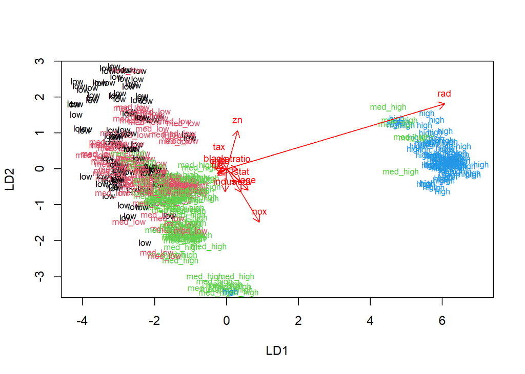

```r
# this is a function from the datacamp course for the arrows for the plot
lda.arrows = function(x, myscale = 1, arrow_heads = 0.1, color = "red", tex = 0.75, choices = c(1,2)){
  heads = coef(x)
  arrows(x0 = 0, y0 = 0,
         x1 = myscale * heads[,choices[1]],
         y1 = myscale * heads[,choices[2]], col=color, length = arrow_heads)
  text(myscale * heads[,choices], labels = row.names(heads),
       cex = tex, col=color, pos=3)
}

#next is the actual plot with the arrows added
plot(lda.fit, dimen = 2, col = as.numeric(train$crime), pch = as.numeric(train$crime))
lda.arrows(lda.fit, myscale = 2)
```

You may notice that this looks like a negative of the data camp results, this is because the datacamp actually has stored in the exercise a different order of variables (high, low, med_high, med_low) and this uses the order (low, med_low, med_high, high). The models are otherwise identical and the random sampling only gives a small variance to the results.

Next we will predict the classes of of the crime variable to the test data.

```r
# predict classes with test data
lda.pred <- predict(lda.fit, newdata = test)

# cross tabulate the results
table(correct = correct_classes, predicted = lda.pred$class)
```

```
##           predicted
## correct    low med_low med_high high
##   low       11       5        2    0
##   med_low    6      11       14    0
##   med_high   0       6       20    0
##   high       0       0        0   27
```

The results are similar to the datacamp results with the high crime rate prediction being the best. For the others there is some deviance and the results seem a bit worse. Again the order of the categories is different here.